# 3. Data Analysis

## Análise dos dados

##### Wellington R Monteiro

A intenção deste notebook é a de analisar os dados gerados nos notebooks anteriores. Sendo assim, os notebooks **1. Text Analysis** e **2. Data Preparation** devem ser executados anteriormente e em sequência.

```python
import pandas as pd
import geopandas as gpd
import numpy as np
import seaborn as sns
import matplotlib.pyplot as plt
import scipy.stats as stats
import unidecode
import glob, os

from sklearn import preprocessing
from pandas_profiling import ProfileReport
from itertools import chain
from collections import Counter
from fbprophet import Prophet
from fbprophet.plot import add_changepoints_to_plot
from sklearn.model_selection import train_test_split
from lightgbm import LGBMClassifier
from xgboost import XGBClassifier
from sklearn.ensemble import RandomForestClassifier, BaggingClassifier, VotingClassifier
from sklearn.metrics import multilabel_confusion_matrix
```

```python
pd.set_option('display.max_columns', None)
pd.set_option('display.max_rows', None)
```

##### Importando os shapefiles das cidades para o geopandas.

```python
shp_folder = 'shp/'
```

```python
cities = None
for file in glob.glob(shp_folder + '*.shp'):
    if cities is not None:
        cities = pd.concat([cities, gpd.read_file(file)])
    else:
        cities = gpd.read_file(file)

# removendo acentuações e deixando os nomes das cidades em minúscula para ficarem compatíveis com o formato da Olist
cities['Municipio'] = cities['NM_MUNICIP'].str.lower().apply(lambda x: unidecode.unidecode(x))

# convertendo os códigos de município para as suas respectivas UFs
cities['UF'] = cities['CD_GEOCODM'].str[:2].map({'41': 'PR', '42': 'SC', '43': 'RS', \
                                         '35': 'SP', '33': 'RJ', '32': 'ES', \
                                         '31': 'MG', '51': 'MT', '50': 'MS', \
                                         '52': 'GO', '53': 'DF', '29': 'BA', '22': 'PI', \
                                         '21': 'MA', '23': 'CE', '24': 'RN', '25': 'PB', \
                                         '26': 'PE', '27': 'AL', '28': 'SE', '12': 'AC', \
                                         '11': 'RO', '14': 'RR', '13': 'AM', '15': 'PA', \
                                         '17': 'TO', '16': 'AP'})
```

##### Importando o dataset concatenado da Olist

```python
dataset_folder = 'datasets/'
```

```python
df = pd.read_csv(dataset_folder + 'dataset_prepared.csv', sep=',', encoding='utf-8').drop_duplicates()
df['order_purchase_timestamp'] = pd.to_datetime(df['order_purchase_timestamp'])
df['order_approved_at'] = pd.to_datetime(df['order_approved_at'])
df['order_delivered_carrier_date'] = pd.to_datetime(df['order_delivered_carrier_date'])
df['order_delivered_customer_date'] = pd.to_datetime(df['order_delivered_customer_date']).dt.date
df['order_estimated_delivery_date'] = pd.to_datetime(df['order_estimated_delivery_date'])
df['shipping_limit_date'] = pd.to_datetime(df['shipping_limit_date'])
df['review_creation_date'] = pd.to_datetime(df['review_creation_date'])
df['review_answer_timestamp'] = pd.to_datetime(df['review_answer_timestamp'])
```

```python
df['customer_region'] = None
df['seller_region'] = None
df.loc[df['customer_state'].isin(['PR', 'SC', 'RS']), 'customer_region'] = 'Sul'
df.loc[df['customer_state'].isin(['SP', 'RJ', 'ES', 'MG']), 'customer_region'] = 'Sudeste'
df.loc[df['customer_state'].isin(['MT', 'MS', 'GO', 'DF']), 'customer_region'] = 'Centro-Oeste'
df.loc[df['customer_state'].isin(['BA', 'PI', 'MA', 'CE', 'RN', 'PB', 'PE', 'AL', 'SE']), 'customer_region'] = 'Nordeste'
df.loc[df['customer_state'].isin(['AC', 'RO', 'RR', 'AM', 'PA', 'TO', 'AP']), 'customer_region'] = 'Norte'

df.loc[df['seller_state'].isin(['PR', 'SC', 'RS']), 'seller_region'] = 'Sul'
df.loc[df['seller_state'].isin(['SP', 'RJ', 'ES', 'MG']), 'seller_region'] = 'Sudeste'
df.loc[df['seller_state'].isin(['MT', 'MS', 'GO', 'DF']), 'seller_region'] = 'Centro-Oeste'
df.loc[df['seller_state'].isin(['BA', 'PI', 'MA', 'CE', 'RN', 'PB', 'PE', 'AL', 'SE']), 'seller_region'] = 'Nordeste'
df.loc[df['seller_state'].isin(['AC', 'RO', 'RR', 'AM', 'PA', 'TO', 'AP']), 'seller_region'] = 'Norte'
```

```python
#substituindo casos onde a diferença é inválida (onde uma das datas era 1900 e
#houve um fillna() por 1900 para conseguir fazer a conversão adequadamente)
df[df['order_delivery_estimated_real_difference'].abs() > 500] = None
df[df['order_delivery_estimated_real_difference_excl_weekend'].abs() > 500] = None
df[df['order_purchase_approval_difference'].abs() > 500] = None
df[df['order_approval_carrier_difference'].abs() > 500] = None
df[df['order_approval_delivery_difference'].abs() > 500] = None
df.head()
```

|  | order_id | customer_id | order_status | order_purchase_timestamp | order_approved_at | order_delivered_carrier_date | order_delivered_customer_date | order_estimated_delivery_date | order_purchase_wday | order_approval_wday | order_delivery_carrier_wday | order_delivery_customer_wday | order_delivery_estimate_wday | order_delivery_estimated_real_difference | order_delivery_estimated_real_difference_excl_weekend | order_purchase_approval_difference | order_approval_carrier_difference | order_approval_delivery_difference | review_score | review_comment_title | review_comment_message | review_creation_date | review_answer_timestamp | title_len | comment_len | TitleSentiment | TitleSentimentScore | ContentSentiment | ContentSentimentScore | … |
| --- | --- | --- | --- | --- | --- | --- | --- | --- | --- | --- | --- | --- | --- | --- | --- | --- | --- | --- | --- | --- | --- | --- | --- | --- | --- | --- | --- | --- | --- | --- |
| 0 | e481f51cbdc54678b7cc49136f2d6af7 | 9ef432eb6251297304e76186b10a928d | delivered | 2017-10-02 10:56:33 | 2017-10-02 11:07:15 | 2017-10-04 19:55:00 | 2017-10-10 | 2017-10-18 | 0.0 | 0.0 | 2.0 | 1.0 | 2.0 | -8.0 | -6.0 | 0.0 | 2.0 | 15.0 | 4.0 | NaN | nao testei o produto ainda, mas ele veio corre... | 2017-10-11 | 2017-10-12 03:43:48 | 0.0 | 170.0 | NaN | NaN | NEGATIVE | 0.520677 | … |
| 3 | 53cdb2fc8bc7dce0b6741e2150273451 | b0830fb4747a6c6d20dea0b8c802d7ef | delivered | 2018-07-24 20:41:37 | 2018-07-26 03:24:27 | 2018-07-26 14:31:00 | 2018-08-07 | 2018-08-13 | 1.0 | 3.0 | 3.0 | 1.0 | 0.0 | -6.0 | -4.0 | 1.0 | 0.0 | 17.0 | 4.0 | muito boa a loja | muito bom o produto. | 2018-08-08 | 2018-08-08 18:37:50 | 16.0 | 20.0 | POSITIVE | 0.999774 | POSITIVE | 0.999920 | … |
| 4 | 47770eb9100c2d0c44946d9cf07ec65d | 41ce2a54c0b03bf3443c3d931a367089 | delivered | 2018-08-08 08:38:49 | 2018-08-08 08:55:23 | 2018-08-08 13:50:00 | 2018-08-17 | 2018-09-04 | 2.0 | 2.0 | 2.0 | 4.0 | 1.0 | -18.0 | -12.0 | 0.0 | 0.0 | 26.0 | 5.0 | NaN | NaN | 2018-08-18 | 2018-08-22 19:07:58 | 0.0 | 0.0 | NaN | NaN | NaN | NaN | … |
| 5 | 949d5b44dbf5de918fe9c16f97b45f8a | f88197465ea7920adcdbec7375364d82 | delivered | 2017-11-18 19:28:06 | 2017-11-18 19:45:59 | 2017-11-22 13:39:59 | 2017-12-02 | 2017-12-15 | 5.0 | 5.0 | 2.0 | 5.0 | 4.0 | -13.0 | -9.0 | 0.0 | 3.0 | 26.0 | 5.0 | NaN | o produto foi exatamente o que eu esperava e e... | 2017-12-03 | 2017-12-05 19:21:58 | 0.0 | 105.0 | NaN | NaN | POSITIVE | 0.999882 | … |
| 6 | ad21c59c0840e6cb83a9ceb5573f8159 | 8ab97904e6daea8866dbdbc4fb7aad2c | delivered | 2018-02-13 21:18:39 | 2018-02-13 22:20:29 | 2018-02-14 19:46:34 | 2018-02-16 | 2018-02-26 | 1.0 | 1.0 | 2.0 | 4.0 | 0.0 | -10.0 | -6.0 | 0.0 | 0.0 | 12.0 | 5.0 | NaN | NaN | 2018-02-17 | 2018-02-18 13:02:51 | 0.0 | 0.0 | NaN | NaN | NaN | NaN | … |

##### Gerando o profile report em um arquivo separado

```python
# removendo identificadores e demais colunas que não são interessantes de se comparar por correlação
profile = ProfileReport(df.drop(['customer_id', 'product_id', 'seller_id', 'order_purchase_timestamp', \
                                 'order_approved_at', 'order_delivered_carrier_date', 'order_delivered_customer_date', \
                                 'order_estimated_delivery_date', 'review_creation_date', 'review_answer_timestamp', \
                                 'shipping_limit_date', 'customer_unique_id', 'seller_lat', 'seller_lng', \
                                 'customer_lat', 'customer_lng', 'ContentKeyEntities', 'customer_zip_code_prefix', \
                                 'seller_zip_code_prefix'], axis=1), html={'style':{'full_width':True}})
profile.to_file("3_analysis_output.html")
```

##### Comentários a partir da análise do profile report

Baseando-se na análise acima (do pandas-profiling salva em um arquivo externo para reduzir o consumo de memória e dos gráficos) as seguintes decisões e observações são feitas:

- 3420 de 119151 itens não estão com o status de entregue e serão removidos;
- Mais de 60 mil itens receberam nota 5 e mais de 20 mil itens receberam nota 1 ou 2, indicando um bom nível na amostra ainda que estejam desbalanceados;
- 3548 de 119151 itens não possuem coordenadas e/ou as cidades de origem e destino válidas e serão removidos.
- Um total de 3555 itens serão removidos (considerando todos com o status incorreto e/ou coordenadas e cidades incorretas).

```python
df = df[(df['customer_lng'] != 0) & (df['seller_lng'] != 0) & ~df['customer_state'].isnull() & \
        ~df['seller_state'].isnull() & (df['order_status']=='delivered')]
```

```python
sns.set(style="whitegrid")
```

##### Análise gráfica

As seguintes análises serão feitas (todas elas utilizando a classificação por Jenks Natural Breaks:

- Número de vendedores por região;
- Volume em kg vendidos por região;
- Número de compradores por região;
- Volume em kg comprados por região.

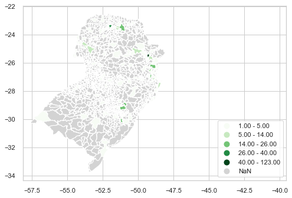

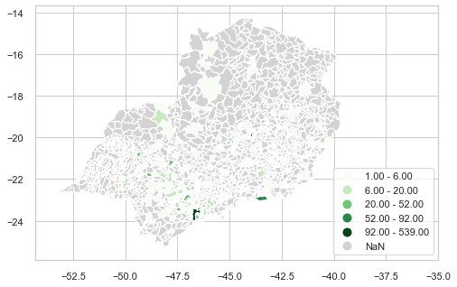

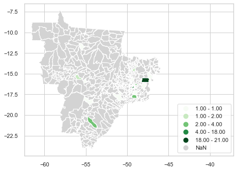

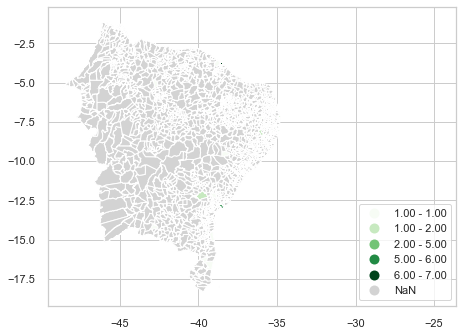

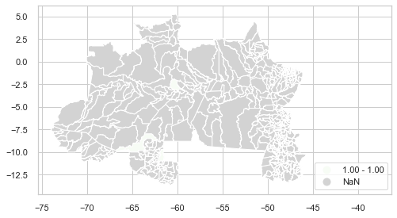

```python
df_sellers_by_city = df[['seller_id', 'seller_city', 'seller_state']].drop_duplicates() \
.groupby(['seller_city', 'seller_state'], as_index=False).count()
df_sellers_by_city = gpd.GeoDataFrame(cities.merge(df_sellers_by_city, how='left', left_on=['Municipio', 'UF'], \
                                                right_on=['seller_city', 'seller_state']))

for region in [['PR', 'SC', 'RS'], ['SP', 'RJ', 'ES', 'MG'], ['MT', 'MS', 'GO', 'DF'], \
['BA', 'PI', 'MA', 'CE', 'RN', 'PB', 'PE', 'AL', 'SE'], ['AC', 'RO', 'RR', 'AM', 'PA', 'TO', 'AP']]:
    plt.figure(figsize=(15,15))
    ax = df_sellers_by_city[df_sellers_by_city['UF'].isin(region)].plot(column='seller_id', scheme='NaturalBreaks', \
                                                                cmap='Greens', missing_kwds={'color': 'lightgrey'}, \
                                                                legend_kwds={'loc': 'lower right'}, legend=True)
    current_limits = ax.axes.get_xlim()
    ax.axes.set_xlim(current_limits[0], current_limits[1] + 8 if current_limits[1] <= -30 else -35)
    plt.show()
```

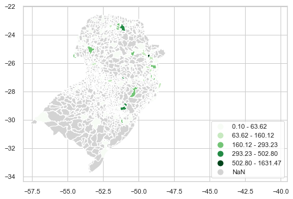

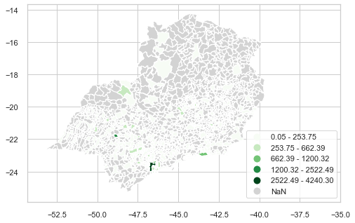

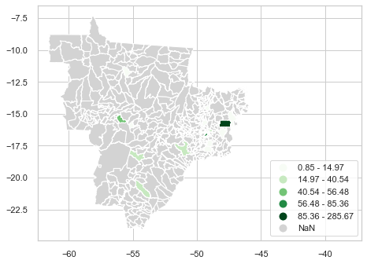

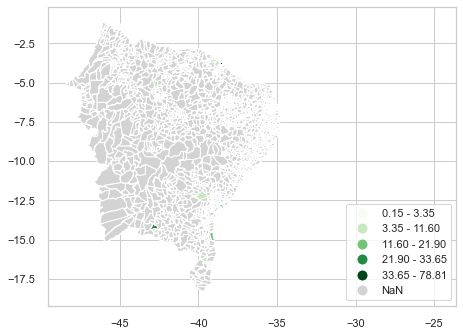

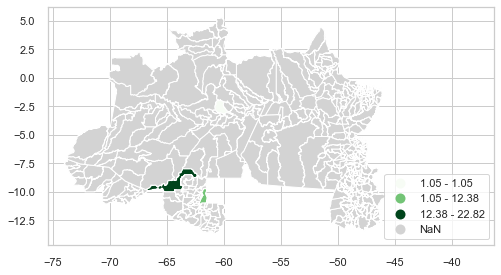

```python
df_qty_sold_by_city = df[['product_weight_g', 'seller_city', 'seller_state']].drop_duplicates() \
.groupby(['seller_city', 'seller_state'], as_index=False).sum()
df_qty_sold_by_city['product_weight_kg'] = df_qty_sold_by_city['product_weight_g'] / 1000
df_qty_sold_by_city = gpd.GeoDataFrame(cities.merge(df_qty_sold_by_city, how='left', left_on=['Municipio', 'UF'], \
                                                right_on=['seller_city', 'seller_state']))

for region in [['PR', 'SC', 'RS'], ['SP', 'RJ', 'ES', 'MG'], ['MT', 'MS', 'GO', 'DF'], \
['BA', 'PI', 'MA', 'CE', 'RN', 'PB', 'PE', 'AL', 'SE'], ['AC', 'RO', 'RR', 'AM', 'PA', 'TO', 'AP']]:
    plt.figure(figsize=(15,15))
    ax = df_qty_sold_by_city[df_qty_sold_by_city['UF'].isin(region)].plot(column='product_weight_kg', scheme='NaturalBreaks', \
                                                                cmap='Greens', missing_kwds={'color': 'lightgrey'}, \
                                                                legend_kwds={'loc': 'lower right'}, legend=True)
    current_limits = ax.axes.get_xlim()
    ax.axes.set_xlim(current_limits[0], current_limits[1] + 8 if current_limits[1] <= -30 else -35)
    plt.show()
```

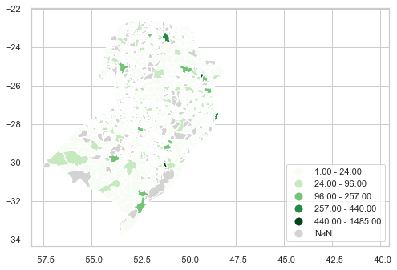

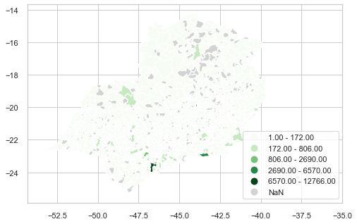

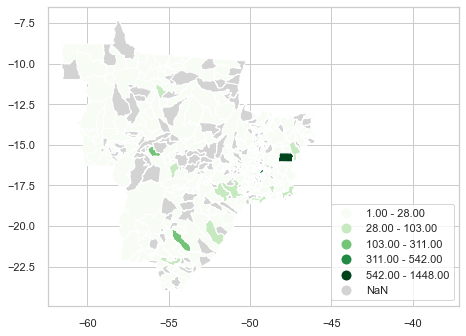

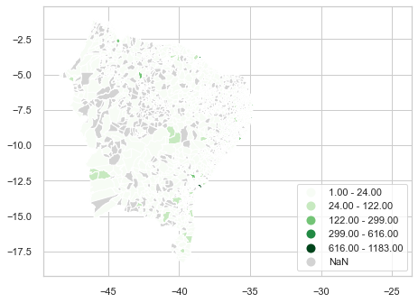

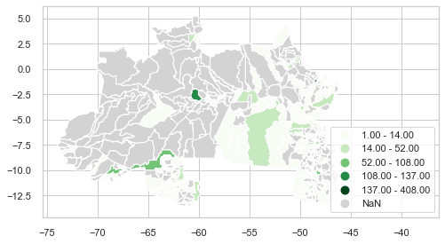

```python
df_customers_by_city = df[['customer_id', 'customer_city', 'customer_state']].drop_duplicates() \
.groupby(['customer_city', 'customer_state'], as_index=False).count()
df_customers_by_city = gpd.GeoDataFrame(cities.merge(df_customers_by_city, how='left', left_on=['Municipio', 'UF'], \
                                                right_on=['customer_city', 'customer_state']))

for region in [['PR', 'SC', 'RS'], ['SP', 'RJ', 'ES', 'MG'], ['MT', 'MS', 'GO', 'DF'], \
['BA', 'PI', 'MA', 'CE', 'RN', 'PB', 'PE', 'AL', 'SE'], ['AC', 'RO', 'RR', 'AM', 'PA', 'TO', 'AP']]:
    plt.figure(figsize=(15,15))
    ax = df_customers_by_city[df_customers_by_city['UF'].isin(region)].plot(column='customer_id', scheme='NaturalBreaks', \
                                                                cmap='Greens', missing_kwds={'color': 'lightgrey'}, \
                                                                legend_kwds={'loc': 'lower right'}, legend=True)
    current_limits = ax.axes.get_xlim()
    ax.axes.set_xlim(current_limits[0], current_limits[1] + 8 if current_limits[1] <= -30 else -35)
    plt.show()
```

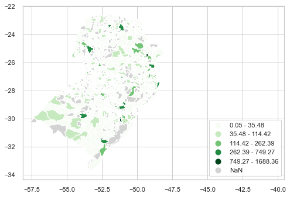

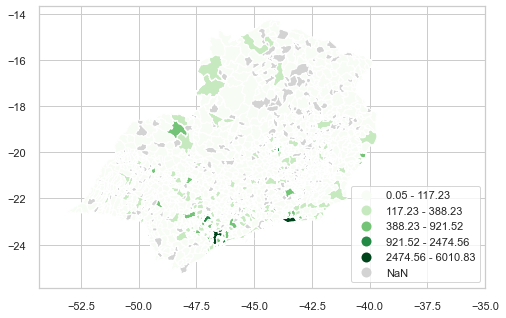

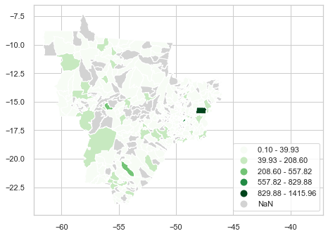

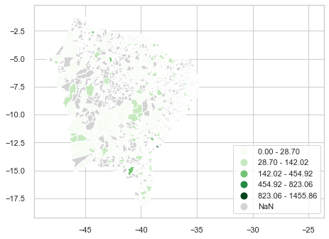

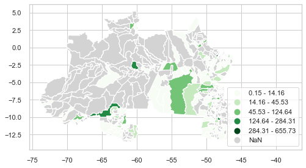

```python
df_qty_purchased_by_city = df[['product_weight_g', 'customer_city', 'customer_state']].drop_duplicates() \
.groupby(['customer_city', 'customer_state'], as_index=False).sum()
df_qty_purchased_by_city['product_weight_kg'] = df_qty_purchased_by_city['product_weight_g'] / 1000
df_qty_purchased_by_city = gpd.GeoDataFrame(cities.merge(df_qty_purchased_by_city, how='left', left_on=['Municipio', 'UF'], \
                                                right_on=['customer_city', 'customer_state']))

for region in [['PR', 'SC', 'RS'], ['SP', 'RJ', 'ES', 'MG'], ['MT', 'MS', 'GO', 'DF'], \
['BA', 'PI', 'MA', 'CE', 'RN', 'PB', 'PE', 'AL', 'SE'], ['AC', 'RO', 'RR', 'AM', 'PA', 'TO', 'AP']]:
    plt.figure(figsize=(15,15))
    ax = df_qty_purchased_by_city[df_qty_purchased_by_city['UF'].isin(region)].plot(column='product_weight_kg', scheme='NaturalBreaks', \
                                                                cmap='Greens', missing_kwds={'color': 'lightgrey'}, \
                                                                legend_kwds={'loc': 'lower right'}, legend=True)
    current_limits = ax.axes.get_xlim()
    ax.axes.set_xlim(current_limits[0], current_limits[1] + 8 if current_limits[1] <= -30 else -35)
    plt.show()
```

##### Comentários

Nota-se que existe um bom volume de vendedores em Curitiba, na região norte do Paraná e na região nordeste do Rio Grande do Sul. Também existem vários vendedores nas capitais de São Paulo, Rio de Janeiro e um volume menor espalhado pelo interior de São Paulo. No Centro-Oeste, a maior quantidade de vendedores fica no Distrito Federal. Já no Norte e Nordeste não existe um volume representativo de vendedores. Quanto aos volumes, nota-se volumes maiores de venda nas regiões nordeste do Rio Grande do Sul, norte do Paraná, Curitiba, São Paulo e Brasília *relativos ao país*. Quanto à quantidade e volumes de compra eles tendem a se acumular nas capitais do país. Sendo assim, baseando neste tipo de análise e nas distâncias além de considerar que um CD pode atender a mais de um estado ou região sugere-se que os centros de distribuição sejam localizados nas seguintes regiões:

- Sul: Paranaguá e Porto Alegre
- Sudeste: Campinas e Rio de Janeiro
- Centro-Oeste: Campo Grande e Brasília
- Norte: Porto Velho, Belém e, opcionalmente, Manaus
- Nordeste: Salvador

##### Análise por mapa de calor

Abaixo é feita uma análise por mapa de calor tanto pelo total de vendas como a média do score nas reviews. A análise do total de vendas é feita com e sem a presença de SP uma vez que este estado acaba desviando muito os resultados.

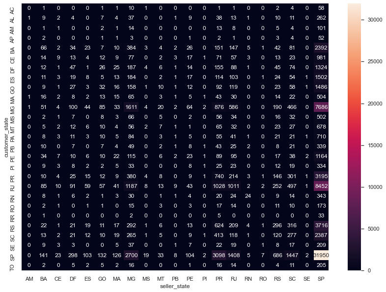

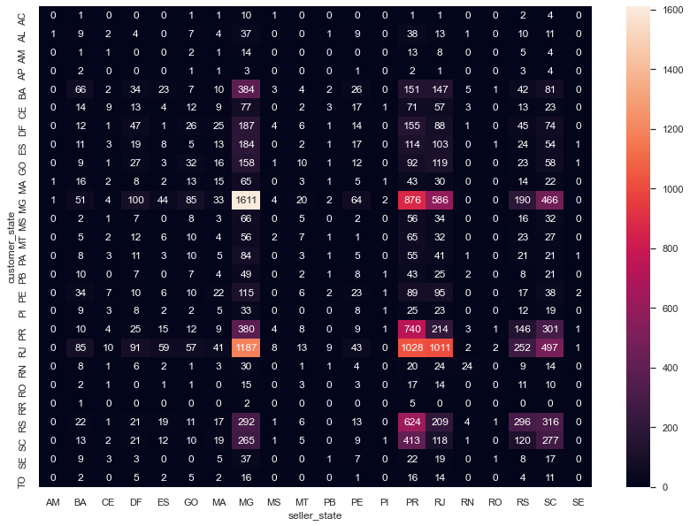

```python
df_routes = df[['customer_state', 'seller_state', 'order_status']]. \
groupby(['customer_state', 'seller_state'], as_index=False).count().rename(columns={'order_status':'items_count'})

df_routes_sp = pd.pivot_table(df_routes, \
               values='items_count', index=['customer_state'], columns=['seller_state']).fillna(0).astype(int)

plt.figure(figsize=(14,10))
ax = sns.heatmap(df_routes_sp, annot=True, fmt='d')
plt.show()

df_routes_sem_sp = pd.pivot_table(df_routes[(df_routes['customer_state'] != 'SP') & (df_routes['seller_state'] != 'SP')], \
               values='items_count', index=['customer_state'], columns=['seller_state']).fillna(0).astype(int)

plt.figure(figsize=(14,10))
ax = sns.heatmap(df_routes_sem_sp, annot=True, fmt='d')
plt.show()
```

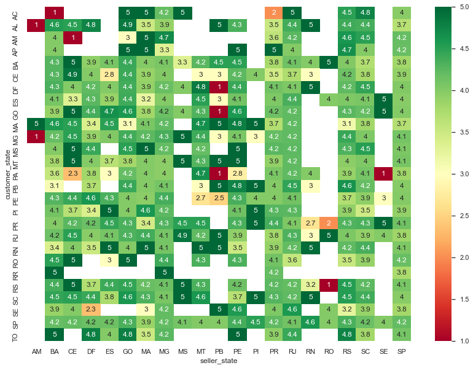

```python
df_routes = df[['customer_state', 'seller_state', 'review_score']]. \
groupby(['customer_state', 'seller_state'], as_index=False).mean()

df_routes_sp = pd.pivot_table(df_routes, \
               values='review_score', index=['customer_state'], columns=['seller_state'])

plt.figure(figsize=(14,10))
ax = sns.heatmap(df_routes_sp, annot=True, cmap='RdYlGn')
plt.show()
```

##### Comentários

Nota-se que SP tende a vender muito para SP, seguido por RJ, MG, BA e os estados do Sul. Ele também tende a comprar muito de MG, PR, RJ e SC, mas comparando com SP em si a quantidade é bem menor. Excetuando-se SP existem clusters de compra e venda distintos (MG para MG e RJ; PR para RJ, MG e o Sul; RJ para RJ e MG). Analisando os scores existe uma tendência deles serem menores com o avanço da distância. Isto será analisado em maior profundidade posteriormente, mas por ora sugere-se a modificação na sugestão da disposição dos CDs para:

- Sul: Ponta Grossa, Itajaí e Porto Alegre
- Sudeste: Campinas, Belo Horizonte e Rio de Janeiro
- Centro-Oeste: Campo Grande e Brasília
- Norte: Porto Velho, Belém e, opcionalmente, Manaus
- Nordeste: Salvador

##### Análise temporal

As análises abaixo observarão o comportamento da média das notas e nas datas de entrega ao longo do tempo.

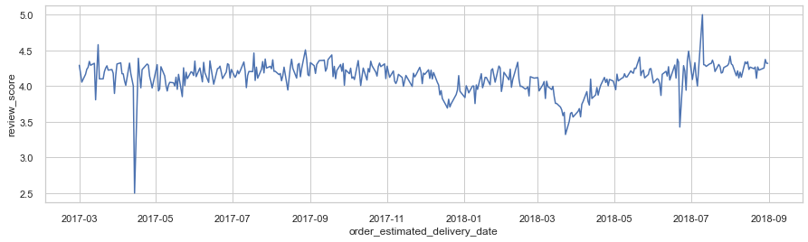

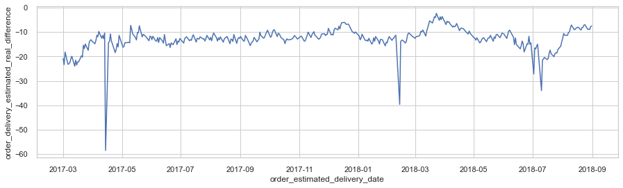

```python
# filtrando pelas entradas entre 03/2017 e 08/2018 pelo volume de dados
df_differences = df.groupby('order_estimated_delivery_date', as_index=False).mean()[['review_score', 'order_estimated_delivery_date', 'order_delivery_estimated_real_difference']]
df_differences = df_differences[(df_differences['order_estimated_delivery_date'] >= '2017-03-01') & (df_differences['order_estimated_delivery_date'] <= '2018-08-31')]

plt.figure(figsize=(15,4))
ax = sns.lineplot(y='review_score', x='order_estimated_delivery_date', data=df_differences)
plt.show()

plt.figure(figsize=(15,4))
ax = sns.lineplot(y='order_delivery_estimated_real_difference', x='order_estimated_delivery_date', data=df_differences)
plt.show()
```

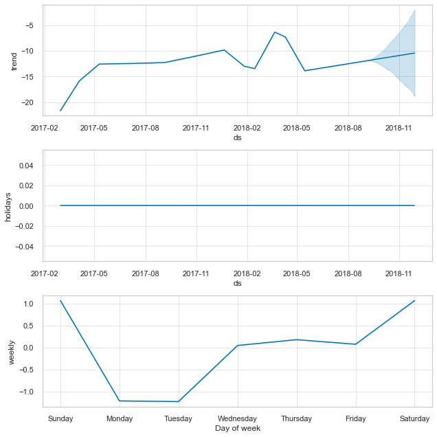

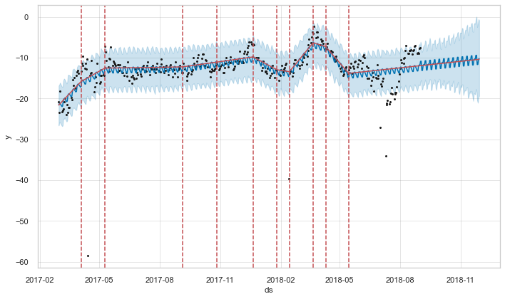

```python
m = Prophet(daily_seasonality=False, yearly_seasonality=False, changepoint_prior_scale=0.5)
m.add_country_holidays(country_name='BR')
m.fit(df_differences.rename(columns={'order_estimated_delivery_date': 'ds', 'order_delivery_estimated_real_difference': 'y'}))

future = m.make_future_dataframe(periods=90)
forecast = m.predict(future)

fig_comp = m.plot_components(forecast)

fig_plot = m.plot(forecast);
a = add_changepoints_to_plot(fig_plot.gca(), m, forecast)
```

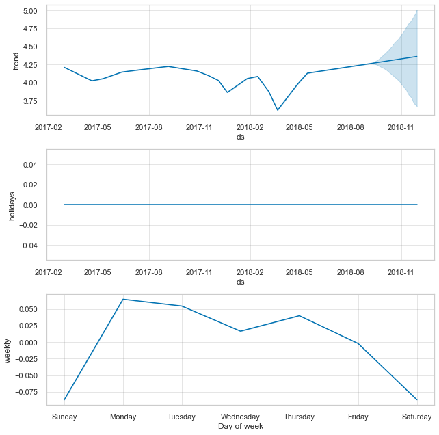

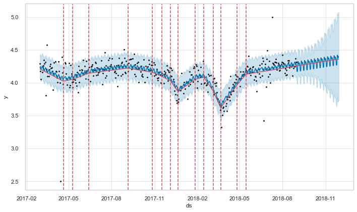

```python
m = Prophet(daily_seasonality=False, yearly_seasonality=False, changepoint_prior_scale=0.5)
m.add_country_holidays(country_name='BR')
m.fit(df_differences.rename(columns={'order_estimated_delivery_date': 'ds', 'review_score': 'y'}))

future = m.make_future_dataframe(periods=90)
forecast = m.predict(future)

fig_comp = m.plot_components(forecast)

fig_plot = m.plot(forecast);
a = add_changepoints_to_plot(fig_plot.gca(), m, forecast)
```

##### Análise das distribuições

As análises abaixo observarão o comportamento no cruzamento de diferentes informações tanto visualmente como por 1-way ANOVA. Preferiu-se fazer por ANOVA para detectar similaridades entre grupos individualmente.

```python
scores = sorted(df['review_score'].dropna().unique())
```

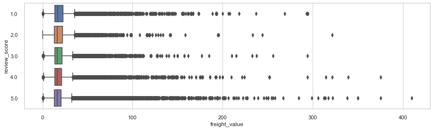

```
'Scores 1.0 e 3.0 são estatisticamente significantes entre eles.'
```

```
'Scores 1.0 e 4.0 são estatisticamente significantes entre eles.'
```

```
'Scores 1.0 e 5.0 são estatisticamente significantes entre eles.'
```

```
'Scores 2.0 e 4.0 são estatisticamente significantes entre eles.'
```

```
'Scores 2.0 e 5.0 são estatisticamente significantes entre eles.'
```

```
'Scores 3.0 e 5.0 são estatisticamente significantes entre eles.'
```

```
'Scores 4.0 e 5.0 são estatisticamente significantes entre eles.'
```

```python
x = 'freight_value'
y = 'review_score'

plt.figure(figsize=(15,4))
ax = sns.boxplot(y=y, x=x, orient='h', data=df)
plt.show()

for score in scores:
    for score_compared in filter(lambda s: s > score, scores):
        _, pvalue = stats.f_oneway(df[df[y]==score][x], df[df[y]==score_compared][x])

        if pvalue <= 0.05:
            display(f'Scores {score} e {score_compared} são estatisticamente significantes entre eles.')
```

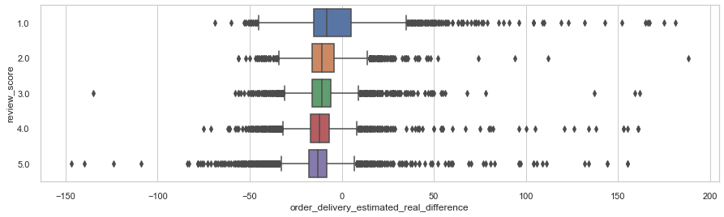

```
'Scores 1.0 e 2.0 são estatisticamente significantes entre eles.'
```

```
'Scores 1.0 e 3.0 são estatisticamente significantes entre eles.'
```

```
'Scores 1.0 e 4.0 são estatisticamente significantes entre eles.'
```

```
'Scores 1.0 e 5.0 são estatisticamente significantes entre eles.'
```

```
'Scores 2.0 e 3.0 são estatisticamente significantes entre eles.'
```

```
'Scores 2.0 e 4.0 são estatisticamente significantes entre eles.'
```

```
'Scores 2.0 e 5.0 são estatisticamente significantes entre eles.'
```

```
'Scores 3.0 e 4.0 são estatisticamente significantes entre eles.'
```

```
'Scores 3.0 e 5.0 são estatisticamente significantes entre eles.'
```

```
'Scores 4.0 e 5.0 são estatisticamente significantes entre eles.'
```

```python
x = 'order_delivery_estimated_real_difference'
y = 'review_score'

plt.figure(figsize=(15,4))
ax = sns.boxplot(y=y, x=x, orient='h', data=df)
plt.show()

for score in scores:
    for score_compared in filter(lambda s: s > score, scores):
        _, pvalue = stats.f_oneway(df[df[y]==score][x], df[df[y]==score_compared][x])

        if pvalue <= 0.05:
            display(f'Scores {score} e {score_compared} são estatisticamente significantes entre eles.')
```

##### Comentários

Para o **preço do frete** existe uma diferença estatisticamente significante entre o score 5 dos demais. Entre o 1 e o 2 ou entre o 2 e o 3 ou, ainda, entre o 3 e o 4 não há uma diferença estatisticamente significante entre eles. Como o frete é inversamente proporcional ao score entende-se que os clientes que pagam mais no frete são mais exigentes na avaliação. Já para o **prazo** um comportamento similar ocorre: todos os scores são estatisticamente significantes nas suas médias entre si - logo, existe uma diferença relevante entre o prazo e a satisfação do cliente.